# AID Clase 2

Cecilia Oliva

01/04/2023

# Muestreo

## Ejemplo: Índice de masa corporal infantil

Consideramos el siguiente conjunto de datos sobre índice de masa corporal infantil.

```r
PACIENTE<-1:30
EDAD<-c(7, 7, 8, 7, 7, 10,7 ,7, 7 ,9, 9, 11, 7, 9,  9, 11, 12, 7, 11,  6,  8,  8,  7, 10,  7,  8, 10,  7,  9, 10)
SEXO<-c("M", "M", "M", "F", "M", "M" ,"M", "M", "M", "M", "M", "F", "M" ,"M" ,"F" ,"M", "M" ,"M" ,"M" ,"F" ,"F" ,"F", "F","F", "M" ,"M" ,"F", "F" ,"F" ,"M")
PESO<-c(24.4, 23.6, 47.0, 24.0, 23.9, 41.0, 32.9, 22.4, 28.7, 31.4, 28.9, 51.2, 26.2, 58.5, 23.7, 25.5, 49.7, 39.6,42.5, 21.6, 38.0, 26.6, 20.4, 23.7, 21.4, 45.7, 51.3, 28.0, 26.9, 43.9)
TALLA<-c(1.2, 1.2, 1.4, 1.2, 1.2, 1.4, 1.3, 1.2, 1.3, 1.3, 1.3, 1.6, 1.3, 1.5, 1.3, 1.3, 1.7, 1.3, 1.5, 1.2, 1.3, 1.2, 1.2,1.3, 1.2, 1.4, 1.5, 1.3, 1.3, 1.5)
IMC<-c(16.94444, 16.38889, 23.97959, 16.66667, 16.59722, 20.91837, 19.46746, 15.55556, 16.98225, 18.57988,17.10059, 20.00000, 15.50296, 26.00000, 14.02367, 15.08876, 17.19723, 23.43195, 18.88889, 15.00000,22.48521, 18.47222, 14.16667, 14.02367, 14.86111, 23.31633, 22.80000, 16.56805, 15.91716, 19.51111)
PIMC<-c(7.97, 72.72, 97.08, 83.88, 45.85, 87.33, 96.57, 32.88, 80.77, 92.72, 55.54, 77.77, 70.70, 98.69,  3.25,2.07, 38.08, 98.75, 80.60, 39.97, 96.07, 71.06,  3.44,  2.02, 56.86, 98.99, 90.84, 57.50, 44.77, 84.89)
CC<-c(54, 52, 76, 63, 56, 78, 69, 52, 60, 69, 60, 75, 50, 88, 58, 73, 75, 76, 72, 52, 76, 54, 52, 56, 56, 78, 76, 57, 57, 76)
CatPeso<-c("N",  "N",  "OB", "N",  "N",  "SO", "OB", "N",  "N",  "SO", "N",  "N",  "N",  "OB", "D",  "D",  "N",  "OB","N" , "N",  "OB", "N",  "D",  "D",  "N",  "OB", "SO", "N",  "N",  "N" )
IMCin<-data.frame(PACIENTE,EDAD,SEXO,PESO,TALLA,IMC,PIMC,CC,CatPeso)

dim(IMCin)#30  9
```

```
## [1] 30  9
```

```r
#View(IMCin)
```

## Muestreo simple

```r
sample(c(1,2,3), size=2, replace=FALSE)#muestra aleatoria simple a partir de un vector de valores con o sin reemplazo
```

```
## [1] 2 3
```

```r
sample(1:100, size=50, replace=FALSE)# sin reemplazo # es igual que sample(100,50,FALSE)
```

```
##  [1]   2  84   9  87 100  50  33  13  94  18  12  29  63  95  53  37  64  70  51
## [20]  89   5  43  38  69  52   7  74  40  77  91  76  39  55  46  86   4  59  41
## [39]  30  23   8  27  16  66  73  56  11  62   1  24
```

```r
sample(1:100, size=50, replace=TRUE)# con reemplazo
```

```
##  [1]  52  11  37  73  97  10  51  24  18  34  87  13  84  45  59  30  31  29  83
## [20]  79  89  21  13  26  12  13   6  69  23  80  31  18  63  14  25  80  73  56
## [39]  64  63  62   4 100  84  61  39  84  98  85  20
```

```r
set.seed(111)#fijo la semilla (dura una operación)
sample(1:100, size=50, replace=TRUE)
```

```
##  [1]  78  84  83  47  25  59  69  35  72  26  49  45  74 100   8  78  90  25  24
## [20]  48  59   7  21  15   1   9  63  40  25  35  71  52 100  28  38  25  61  52
## [39]  68  95  70  30  69  53  37  70 100  64  41  92
```

```r
sample(c("cara","ceca"), 1, prob=c(0.3,0.7))# Ejemplo de moneda cargada (cuando el tamaño o size es 1 no hace falta el argumento replace)
```

```
## [1] "ceca"
```

Repasamos los ejercicios de la clase pasada:

Ejercicio 5: Simular el lanzamiento de un dado.

Ejercicio 6: Simular el lanzamiento de cuatro dados o de un mismo dado cuatro veces.

Ejercicio 7: Supongamos una urna con 3 bolas blancas y 7 negras, simular la extracción de una bola (asignar, por ejemplo, el 1 a bola blanca y 0 a negra).

Ejercicio 8: Simular 8 extracciones con reemplazo de la urna del ejercicio 7.

## Usando paquete dplyr

```r
library(dplyr)
#Muestra sin reemplazo
IMCin_muestra<- IMCin %>%
  sample_n(size=10,replace=FALSE)
IMCin_muestra
```

| PACIENTE | EDAD | SEXO | PESO | TALLA | IMC | PIMC | CC | CatPeso |
| --- | --- | --- | --- | --- | --- | --- | --- | --- |
| 18 | 7 | M | 39.6 | 1.3 | 23.43195 | 98.75 | 76 | OB |
| 26 | 8 | M | 45.7 | 1.4 | 23.31633 | 98.99 | 78 | OB |
| 24 | 10 | F | 23.7 | 1.3 | 14.02367 | 2.02 | 56 | D |
| 27 | 10 | F | 51.3 | 1.5 | 22.80000 | 90.84 | 76 | SO |
| 23 | 7 | F | 20.4 | 1.2 | 14.16667 | 3.44 | 52 | D |
| 21 | 8 | F | 38.0 | 1.3 | 22.48521 | 96.07 | 76 | OB |
| 13 | 7 | M | 26.2 | 1.3 | 15.50296 | 70.70 | 50 | N |
| 1 | 7 | M | 24.4 | 1.2 | 16.94444 | 7.97 | 54 | N |
| 10 | 9 | M | 31.4 | 1.3 | 18.57988 | 92.72 | 69 | SO |
| 16 | 11 | M | 25.5 | 1.3 | 15.08876 | 2.07 | 73 | D |

```r
#Muestra con pesos (deben ser positivos y de la misma longitud que la cantidad de filas del dataframe)
IMCin_muestra2<- IMCin %>%
  sample_n(size=10,weight=PIMC)
IMCin_muestra2
```

| PACIENTE | EDAD | SEXO | PESO | TALLA | IMC | PIMC | CC | CatPeso |
| --- | --- | --- | --- | --- | --- | --- | --- | --- |
| 6 | 10 | M | 41.0 | 1.4 | 20.91837 | 87.33 | 78 | SO |
| 26 | 8 | M | 45.7 | 1.4 | 23.31633 | 98.99 | 78 | OB |
| 12 | 11 | F | 51.2 | 1.6 | 20.00000 | 77.77 | 75 | N |
| 30 | 10 | M | 43.9 | 1.5 | 19.51111 | 84.89 | 76 | N |
| 21 | 8 | F | 38.0 | 1.3 | 22.48521 | 96.07 | 76 | OB |
| 8 | 7 | M | 22.4 | 1.2 | 15.55556 | 32.88 | 52 | N |
| 14 | 9 | M | 58.5 | 1.5 | 26.00000 | 98.69 | 88 | OB |
| 25 | 7 | M | 21.4 | 1.2 | 14.86111 | 56.86 | 56 | N |
| 3 | 8 | M | 47.0 | 1.4 | 23.97959 | 97.08 | 76 | OB |
| 29 | 9 | F | 26.9 | 1.3 | 15.91716 | 44.77 | 57 | N |

```r
#Muestra con una proporción de casos
IMCin_muestra3<- IMCin %>%
  sample_frac(0.1)
IMCin_muestra3
```

| PACIENTE | EDAD | SEXO | PESO | TALLA | IMC | PIMC | CC | CatPeso |
| --- | --- | --- | --- | --- | --- | --- | --- | --- |
| 16 | 11 | M | 25.5 | 1.3 | 15.08876 | 2.07 | 73 | D |
| 29 | 9 | F | 26.9 | 1.3 | 15.91716 | 44.77 | 57 | N |
| 13 | 7 | M | 26.2 | 1.3 | 15.50296 | 70.70 | 50 | N |

## Muestreo estratificado

```r
muestra_estrat_0 <- IMCin%>%
  group_by(SEXO)%>%
  sample_n(10)

muestra_estrat_0
```

| PACIENTE | EDAD | SEXO | PESO | TALLA | IMC | PIMC | CC | CatPeso |
| --- | --- | --- | --- | --- | --- | --- | --- | --- |
| 15 | 9 | F | 23.7 | 1.3 | 14.02367 | 3.25 | 58 | D |
| 28 | 7 | F | 28.0 | 1.3 | 16.56805 | 57.50 | 57 | N |
| 24 | 10 | F | 23.7 | 1.3 | 14.02367 | 2.02 | 56 | D |
| 22 | 8 | F | 26.6 | 1.2 | 18.47222 | 71.06 | 54 | N |
| 20 | 6 | F | 21.6 | 1.2 | 15.00000 | 39.97 | 52 | N |
| 12 | 11 | F | 51.2 | 1.6 | 20.00000 | 77.77 | 75 | N |
| 4 | 7 | F | 24.0 | 1.2 | 16.66667 | 83.88 | 63 | N |
| 21 | 8 | F | 38.0 | 1.3 | 22.48521 | 96.07 | 76 | OB |
| 23 | 7 | F | 20.4 | 1.2 | 14.16667 | 3.44 | 52 | D |
| 27 | 10 | F | 51.3 | 1.5 | 22.80000 | 90.84 | 76 | SO |

[output cut: 10 more lines]

Notamos que, en este caso, no se mantienen las proporciones originales de las categorías de la variable SEXO.

```r
table(SEXO)
```

```
## SEXO
##  F  M
## 11 19
```

```r
muestra_estrat_1 <- IMCin%>%
  group_by(CatPeso)%>%
  sample_frac(0.1)

muestra_estrat_1
```

| PACIENTE | EDAD | SEXO | PESO | TALLA | IMC | PIMC | CC | CatPeso |
| --- | --- | --- | --- | --- | --- | --- | --- | --- |
| 13 | 7 | M | 26.2 | 1.3 | 15.50296 | 70.70 | 50 | N |
| 20 | 6 | F | 21.6 | 1.2 | 15.00000 | 39.97 | 52 | N |
| 7 | 7 | M | 32.9 | 1.3 | 19.46746 | 96.57 | 69 | OB |

```r
table(CatPeso)
```

```
## CatPeso
##  D  N OB SO
##  4 17  6  3
```

```r
muestra_estrat_2 <- IMCin%>%
  group_by(CatPeso)%>%
  sample_frac(0.25)

muestra_estrat_2
```

| PACIENTE | EDAD | SEXO | PESO | TALLA | IMC | PIMC | CC | CatPeso |
| --- | --- | --- | --- | --- | --- | --- | --- | --- |
| 16 | 11 | M | 25.5 | 1.3 | 15.08876 | 2.07 | 73 | D |
| 22 | 8 | F | 26.6 | 1.2 | 18.47222 | 71.06 | 54 | N |
| 5 | 7 | M | 23.9 | 1.2 | 16.59722 | 45.85 | 56 | N |
| 29 | 9 | F | 26.9 | 1.3 | 15.91716 | 44.77 | 57 | N |
| 8 | 7 | M | 22.4 | 1.2 | 15.55556 | 32.88 | 52 | N |
| 26 | 8 | M | 45.7 | 1.4 | 23.31633 | 98.99 | 78 | OB |
| 18 | 7 | M | 39.6 | 1.3 | 23.43195 | 98.75 | 76 | OB |
| 10 | 9 | M | 31.4 | 1.3 | 18.57988 | 92.72 | 69 | SO |

Comparando con las proporciones originales, aquí sí se mantienen los porcentajes de cada categoría de la variable CatPeso.

## Usando paquete splitstackshape

Recordamos fijar la semilla siempre que se quieran reutilizarse los datos.

```r
library(splitstackshape)
set.seed(2023)
strat_sexo<-stratified(IMCin, "SEXO", 0.7)

table(strat_sexo$SEXO)
```

```
##
##  F  M
##  8 13
```

```r
table(strat_sexo$CatPeso)
```

```
##
##  D  N OB SO
##  3 12  4  2
```

```r
set.seed(2023)
strat_sexo_peso<-stratified(IMCin, c("SEXO","CatPeso"), 0.7)
table(strat_sexo_peso$SEXO)
```

```
##
##  F  M
##  8 14
```

```r
table(strat_sexo_peso$CatPeso)
```

```
##
##  D  N OB SO
##  3 12  5  2
```

Observamos que se mantienen las proporciones originales de las muestras en las variables que son contempladas en el argumento de la función stratified, en principio las otras no tienen necesariamente una distribución similar.

Comparamos cómo se ven afectadas otras variables como EDAD y PESO.

```r
summary(IMCin$EDAD)
```

```
##    Min. 1st Qu.  Median    Mean 3rd Qu.    Max.
##    6.00    7.00    8.00    8.40    9.75   12.00
```

```r
summary(strat_sexo$EDAD)
```

```
##    Min. 1st Qu.  Median    Mean 3rd Qu.    Max.
##   6.000   7.000   8.000   8.476   9.000  12.000
```

```r
summary(strat_sexo_peso$EDAD)
```

```
##    Min. 1st Qu.  Median    Mean 3rd Qu.    Max.
##   6.000   7.000   8.000   8.364   9.000  12.000
```

```r
summary(stratified(IMCin, c("SEXO","CatPeso","EDAD"), 0.7)$EDAD)
```

```
##    Min. 1st Qu.  Median    Mean 3rd Qu.    Max.
##    6.00    7.00    9.00    8.64   10.00   12.00
```

```r
summary(IMCin$PESO)
```

```
##    Min. 1st Qu.  Median    Mean 3rd Qu.    Max.
##   20.40   23.93   28.35   33.09   42.12   58.50
```

```r
summary(strat_sexo$PESO)
```

```
##    Min. 1st Qu.  Median    Mean 3rd Qu.    Max.
##    20.4    23.7    28.7    33.1    41.0    58.5
```

```r
summary(strat_sexo_peso$PESO)
```

```
##    Min. 1st Qu.  Median    Mean 3rd Qu.    Max.
##   21.60   24.02   27.45   33.13   41.77   58.50
```

```r
summary(stratified(IMCin, c("SEXO","CatPeso","PESO"), 0.7)$PESO)
```

```
##    Min. 1st Qu.  Median    Mean 3rd Qu.    Max.
##   20.40   24.00   28.70   33.41   42.50   58.50
```

## Muestreo de conglomerados

```r
set.seed(1)
df <- data.frame(
  Id = 1:100,
  Grupo = sample(c("A", "B", "C", "D", "E", "F", "G", "H", "I", "J"), 100, replace = TRUE),
  Var1 = abs(round(rnorm(100), digits=1)),
  Var2 = sample(1:100, 100, replace = TRUE),
  Sexo = sample(c("M", "F"), 100, replace = TRUE))

df
```

| Id | Grupo | Var1 | Var2 | Sexo |
| --- | --- | --- | --- | --- |
| 1 | I | 1.1 | 53 | M |
| 2 | D | 0.1 | 86 | M |
| 3 | G | 0.1 | 89 | M |
| 4 | A | 0.9 | 24 | F |
| 5 | B | 1.4 | 37 | F |
| 6 | G | 0.8 | 15 | M |
| 7 | B | 1.3 | 14 | M |
| 8 | C | 0.8 | 81 | F |
| 9 | A | 0.2 | 82 | M |
| 10 | E | 0.4 | 97 | F |

[output cut: 90 more lines]

```r
# Seleccionamos 4 grupos/conglomerados de los 10 totales
set.seed(2)
grupos<-sample(unique(df$Grupo), size = 4, replace = F )
grupos
```

```
## [1] "B" "C" "F" "I"
```

```r
#muestreo de conglomerados
muestra_conglomerados<- df[df$Grupo %in%grupos,]

muestra_conglomerados
```

|  | Id | Grupo | Var1 | Var2 | Sexo |
| --- | --- | --- | --- | --- | --- |
| 1 | 1 | I | 1.1 | 53 | M |
| 5 | 5 | B | 1.4 | 37 | F |
| 7 | 7 | B | 1.3 | 14 | M |
| 8 | 8 | C | 0.8 | 81 | F |
| 13 | 13 | F | 0.3 | 53 | F |
| 16 | 16 | I | 1.3 | 91 | M |
| 19 | 19 | I | 0.9 | 20 | M |
| 20 | 20 | I | 0.6 | 98 | M |
| 23 | 23 | B | 1.5 | 2 | M |
| 25 | 25 | I | 1.0 | 38 | M |

[output cut: 29 more lines]

## Muestreo sistemático

```r
MuestreoSistem = function(N, n) {
  k = ceiling(N/n)
  r = sample(1:k, 1)
  muestra = seq(r, r + k * (n - 1), k)
  muestra
}

MuestreoSistem(100,5)
```

```
## [1] 17 37 57 77 97
```

```r
MuestreoSistem(100,50)
```

```
##  [1]   2   4   6   8  10  12  14  16  18  20  22  24  26  28  30  32  34  36  38
## [20]  40  42  44  46  48  50  52  54  56  58  60  62  64  66  68  70  72  74  76
## [39]  78  80  82  84  86  88  90  92  94  96  98 100
```

```r
MuestreoSistem(100,75)
```

```
##  [1]   1   3   5   7   9  11  13  15  17  19  21  23  25  27  29  31  33  35  37
## [20]  39  41  43  45  47  49  51  53  55  57  59  61  63  65  67  69  71  73  75
## [39]  77  79  81  83  85  87  89  91  93  95  97  99 101 103 105 107 109 111 113
## [58] 115 117 119 121 123 125 127 129 131 133 135 137 139 141 143 145 147 149
```

```r
ind<-MuestreoSistem(100,75)
df[ind, ]#contiene NAs por cómo es el algoritmo
```

|  | Id | Grupo | Var1 | Var2 | Sexo |
| --- | --- | --- | --- | --- | --- |
| 1 | 1 | I | 1.1 | 53 | M |
| 3 | 3 | G | 0.1 | 89 | M |
| 5 | 5 | B | 1.4 | 37 | F |
| 7 | 7 | B | 1.3 | 14 | M |
| 9 | 9 | A | 0.2 | 82 | M |
| 11 | 11 | E | 0.4 | 96 | M |
| 13 | 13 | F | 0.3 | 53 | F |
| 15 | 15 | G | 0.6 | 71 | M |
| 17 | 17 | E | 0.9 | 50 | F |
| 19 | 19 | I | 0.9 | 20 | M |

[output cut: 65 more lines]

```r
indice<-MuestreoSistem(nrow(df), nrow(df) * 0.5)# muestra sistemática del 50%
indice
```

```
##  [1]   2   4   6   8  10  12  14  16  18  20  22  24  26  28  30  32  34  36  38
## [20]  40  42  44  46  48  50  52  54  56  58  60  62  64  66  68  70  72  74  76
## [39]  78  80  82  84  86  88  90  92  94  96  98 100
```

```r
df[indice, ]
```

|  | Id | Grupo | Var1 | Var2 | Sexo |
| --- | --- | --- | --- | --- | --- |
| 2 | 2 | D | 0.1 | 86 | M |
| 4 | 4 | A | 0.9 | 24 | F |
| 6 | 6 | G | 0.8 | 15 | M |
| 8 | 8 | C | 0.8 | 81 | F |
| 10 | 10 | E | 0.4 | 97 | F |
| 12 | 12 | J | 1.0 | 72 | F |
| 14 | 14 | J | 1.3 | 56 | M |
| 16 | 16 | I | 1.3 | 91 | M |
| 18 | 18 | E | 0.0 | 73 | F |
| 20 | 20 | I | 0.6 | 98 | M |

[output cut: 40 more lines]

## Generación de muestras aleatorias de distribuciones conocidas y cálculo de probabilidades

### Ejemplos con distribuciones continuas

**Distribución uniforme**

```r
muestra.unif1=runif(100) # genera una muestra uniforme en [0,1] de 100 datos
muestra.unif1 # devuelve la muestra generada
```

```
##   [1] 0.180820101 0.405282181 0.853548453 0.976398489 0.225825461 0.444809229
##   [7] 0.074979425 0.661898758 0.387549543 0.836889177 0.150501441 0.347272249
##  [13] 0.488773231 0.149246863 0.357062590 0.962644048 0.132372003 0.010414525
##  [19] 0.164642242 0.810192144 0.868861037 0.514281763 0.627196287 0.844429003
##  [25] 0.284870574 0.667225648 0.150469752 0.981727862 0.297010735 0.115084075
##  [31] 0.163200872 0.944041808 0.794863824 0.974687898 0.349088411 0.501969881
##  [37] 0.810397263 0.007109038 0.014693911 0.683403423 0.929720222 0.275401199
##  [43] 0.811859695 0.785878913 0.988902156 0.613952910 0.710185730 0.770027857
##  [49] 0.886984157 0.625121730 0.260300035 0.859073118 0.437488002 0.388144758
##  [55] 0.461501105 0.218675193 0.065935510 0.275701027 0.310381097 0.042175526
##  [61] 0.184673463 0.183373228 0.755462416 0.288059732 0.867844662 0.402642736
##  [67] 0.572685004 0.350642575 0.671998928 0.025050357 0.401101038 0.199976530
##  [73] 0.856525001 0.971515429 0.323722437 0.733191433 0.340068240 0.976755185
##  [79] 0.397016412 0.379998879 0.560387630 0.463808179 0.196776827 0.426943403
##  [85] 0.093025187 0.115309127 0.440031654 0.200934730 0.427639073 0.980599982
##  [91] 0.828922126 0.286973855 0.595916897 0.898971946 0.453377000 0.147417779
##  [97] 0.128676983 0.024656338 0.736311375 0.373358564
```

```r
punif(0.5)#P(X<0.5)=0.5
```

```
## [1] 0.5
```

```r
punif(0)#P(X<0)=0
```

```
## [1] 0
```

```r
punif(1)#P(X<1)=1
```

```
## [1] 1
```

```r
muestra.unif2=runif(200,min=2,max=5) # genera una muestra uniforme en [2,5] de 200 datos
muestra.unif2 # devuelve la muestra generada
```

```
##   [1] 3.723131 4.475984 4.441087 4.618089 2.331665 4.858101 3.707006 2.110605
##   [9] 2.735873 4.936654 4.657212 2.722949 4.271635 3.688510 2.915309 4.080962
##  [17] 3.007837 2.618328 4.757829 2.068437 4.891279 2.947596 3.996825 3.600630
##  [25] 4.453390 2.555791 3.198553 2.535360 2.856303 3.888409 2.900301 3.331022
##  [33] 4.190603 4.004491 2.934971 3.435734 2.874230 2.546523 3.082288 4.711400
##  [41] 3.182143 4.339642 2.852477 4.561162 2.516727 2.237793 2.876195 4.521114
##  [49] 4.835804 2.134896 4.275149 2.890664 3.953163 2.254969 4.926443 2.040875
##  [57] 3.616608 4.897345 2.303220 2.770254 4.685442 3.163833 4.382856 3.048190
##  [65] 2.416233 3.951527 3.632013 4.835732 3.715237 4.860901 4.340759 2.354853
##  [73] 4.511335 2.261478 4.245800 2.195545 2.233087 2.315251 3.220059 4.924894
##  [81] 2.494500 3.509151 2.604663 2.599166 2.534405 2.821600 2.391861 4.576075
##  [89] 3.935481 3.808396 4.915942 3.129972 4.457343 2.680216 2.619526 2.582868
##  [97] 2.721705 4.939166 3.572750 4.479112 4.012656 4.933145 2.172945 3.010223
## [105] 2.037821 3.088569 2.629083 2.456362 4.807437 3.203279 3.457509 4.044459
## [113] 4.562106 4.738752 3.427573 4.141041 4.489260 4.027394 3.019105 4.672490
## [121] 3.586488 4.623012 2.775971 3.627338 2.648004 2.650162 3.422122 4.678202
## [129] 2.905151 3.665657 4.265649 4.869276 4.862934 3.000094 3.550052 2.444569
## [137] 3.070459 4.113699 2.241217 2.754683 2.154306 4.215576 2.041276 2.127065
## [145] 2.845460 2.122150 3.896842 4.264524 2.152840 3.888992 3.071327 4.424424
## [153] 4.014993 2.065661 4.068617 4.662064 3.611628 4.655079 4.742524 4.546940
## [161] 2.880528 4.352559 3.481106 4.947722 2.729603 2.218999 2.694970 2.839735
## [169] 4.912881 3.976987 4.010336 2.629516 4.971867 3.602264 3.723118 4.316719
## [177] 3.071268 2.769984 2.949338 4.233331 3.498998 4.126428 3.244689 2.629734
## [185] 2.242588 2.477870 3.512269 4.506322 3.462350 3.298196 4.642075 4.294735
## [193] 2.164583 2.597653 4.060474 4.697752 2.137216 2.268854 3.322630 4.333897
```

```r
punif(3,min=2,max=5,lower.tail = TRUE)#P(X<3)=0.3333333
```

```
## [1] 0.3333333
```

**Distribución normal**

```r
muestra.norm.est=rnorm(30) # genera una muestra normal estándar de 30 datos
muestra.norm.est # devuelve la muestra generada
```

```
##  [1] -1.0799371 -1.6686033 -0.1252964 -0.9262828 -0.9777118 -1.3103580
##  [7] -0.7953044 -0.6507013 -1.4728307  1.1413531 -0.2769228 -1.7002219
## [13]  0.1771404  0.8965851  1.0501126 -2.0593194 -0.3490874  1.3781266
## [19] -0.1292237  0.2381524  1.1435961  0.8760935  0.2660100  0.4996019
## [25] -0.8395728 -2.2364285 -0.6997563 -1.5690086 -1.8727366 -2.1367020
```

```r
pnorm(0)#P(X<0)=0.5
```

```
## [1] 0.5
```

```r
pnorm(-1)#P(X<-1)=0.1586553
```

```
## [1] 0.1586553
```

```r
pnorm(1)#P(X<1)=0.8413447
```

```
## [1] 0.8413447
```

```r
pnorm(1,lower.tail = FALSE)#P(X>=1)=0.1586553
```

```
## [1] 0.1586553
```

```r
1-(pnorm(1))#0.1586553
```

```
## [1] 0.1586553
```

```r
muestra.norm=rnorm(50,mean=10,sd=3) # genera una muestra normal(10,3) de 50 datos
muestra.norm # devuelve la muestra generada
```

```
##  [1] 11.1102197 11.2204871 18.5319863  5.0842585  9.8507906  8.1269228
##  [7] 10.8493847 10.2984225 12.0462568 14.2953285  6.9716059  6.3650552
## [13] 13.2096092 12.1872135 10.5219760  4.5577802 12.9292827  8.7553747
## [19] 12.6051765 11.6218339  5.6215795 11.1320446  9.4132388 12.5024265
## [25]  0.3694129 11.5206948  6.6174867 10.5103910  5.3757460 14.0977491
## [31]  8.6370715 12.8757496 13.3607244  9.9935559  7.4079871 10.3574107
## [37] 11.5025951 10.4236081  7.6487561 11.9860229  6.7240207 12.8882232
## [43] 16.0847623 11.0326554  3.4087676  9.8970976 12.1584563 11.9942739
## [49]  9.5519811  9.5618678
```

```r
pnorm(2,mean=2,sd=1)#0.5
```

```
## [1] 0.5
```

```r
pnorm(3,mean=2,sd=1)#0.8413447
```

```
## [1] 0.8413447
```

```r
pnorm(-1,mean=2,sd=1)#0.001349898
```

```
## [1] 0.001349898
```

```r
pnorm(1,mean=2,sd=1)#0.1586553
```

```
## [1] 0.1586553
```

```r
pnorm(1,mean=2,sd=1,lower.tail = FALSE)#0.8413447
```

```
## [1] 0.8413447
```

```r
1-(pnorm(1,mean=2,sd=1))#0.8413447
```

```
## [1] 0.8413447
```

## Algunos gráficos

```r
library(ggplot2)

media=2
desv=0.3
x1=2
x2=1.5
pnorm(x1,mean=media,sd=desv)-pnorm(x2,mean=media,sd=desv)#P(x1<X<x2)
```

```
## [1] 0.4522096
```

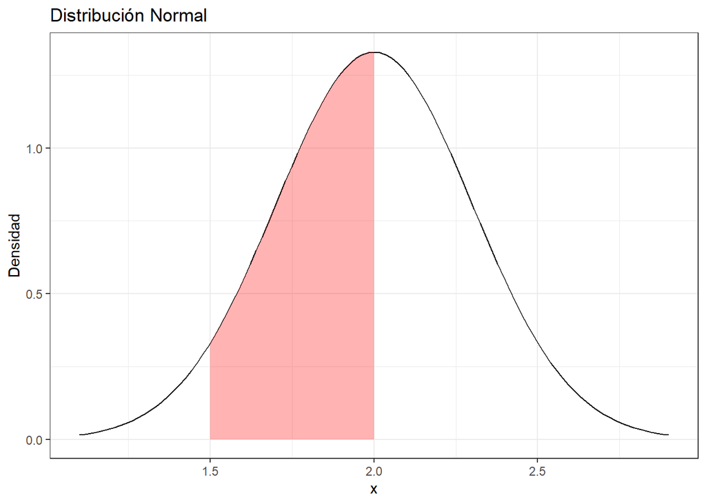

```r
rango=c(media-3*desv, media+3*desv)
ggplot(data.frame(x = rango), aes(x=rango)) +
  stat_function(fun = dnorm, n = 101, args = list(mean = media, sd = desv))+
  geom_area(stat = 'function',fun = dnorm,args = list(mean = media, sd =desv),
            fill = 'red',xlim = c(x2, x1),alpha = 0.3)+
  ylab("Densidad") + ggtitle("Distribución Normal") + xlab("x") + theme_bw()
```

```r
x0=2.3
pnorm(x0,mean=media,sd=desv,lower.tail = FALSE)#P(X>=2.3)
```

```
## [1] 0.1586553
```

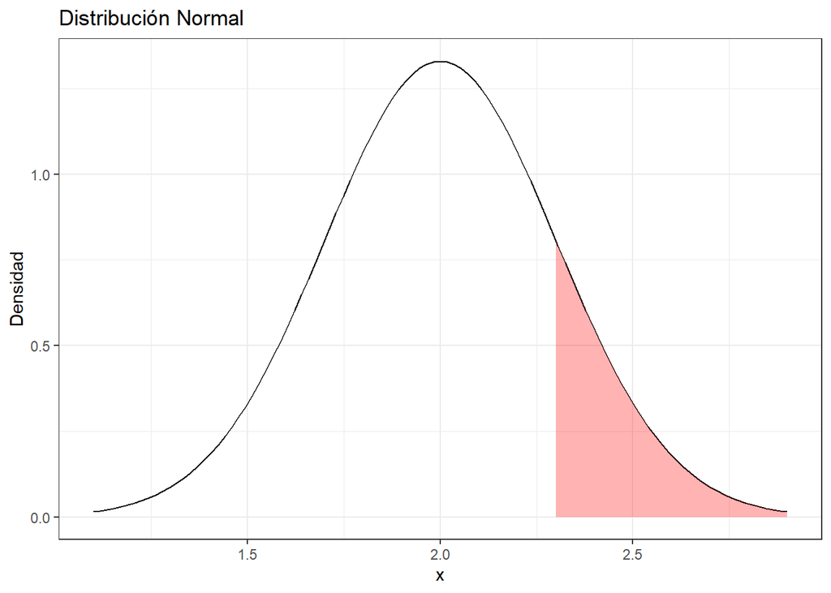

```r
rango=c(media-3*desv, media+3*desv)
ggplot(data.frame(x = rango), aes(x=rango)) +
  stat_function(fun = dnorm, n = 101, args = list(mean = media, sd = desv))+
  geom_area(stat = 'function',fun = dnorm,args = list(mean = media, sd =desv),
            fill = 'red',xlim = c(x0, max(rango)),alpha = 0.3)+
  ylab("Densidad") + ggtitle("Distribución Normal") + xlab("x") + theme_bw()
```

```r
p=0.75
qnorm(p,mean=media,sd=desv)
```

```
## [1] 2.202347
```

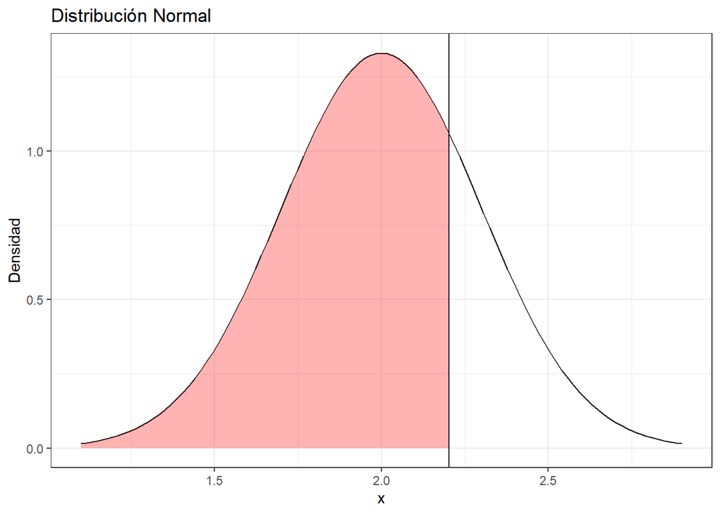

```r
rango=c(media-3*desv, media+3*desv)
ggplot(data.frame(x = rango), aes(x=rango)) +
  stat_function(fun = dnorm, n = 101, args = list(mean = media, sd = desv))+
  geom_area(stat = 'function',fun = dnorm,args = list(mean = media, sd =desv),
            fill = 'red',xlim = c(min(rango), qnorm(p,mean=media,sd=desv)),alpha = 0.3)+
  geom_vline(xintercept=qnorm(p,mean=media,sd=desv))+
  ylab("Densidad") + ggtitle("Distribución Normal") + xlab("x") + theme_bw()
```